# ML from scratch

C. Donovan

# Some ML principles

The purpose here is to look at some general principles that link many ML models.

- The complexity of the model should be adaptive to the data
- Given a particular candidate model, we fit to the with an appropriate loss function
- Choosing between models uses generalisation error - ideally **evaluate models on data not used in their fitting**

We’ll take a simple dataset, and build a familiar model with these principles in mind.

# Some data

We’ll use the ubiquitous `mcycle` data - the acceleration/deceleration of a crash-test dummy, over time, in a motor-cycle crash. It’s popular as it has quite complex signal and errors.

```r
  head(mcycle)
```

```
##   times accel
## 1   2.4   0.0
## 2   2.6  -1.3
## 3   3.2  -2.7
## 4   3.6   0.0
## 5   4.0  -2.7
## 6   6.2  -2.7
```

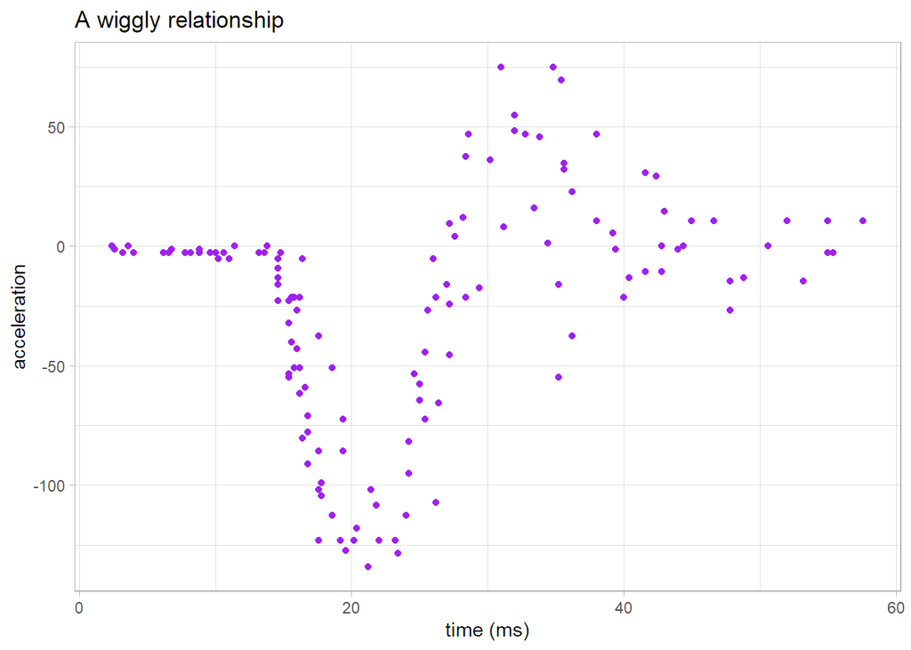

```r
  p <- ggplot(data=mcycle) +
      geom_point(aes(x=times, y=accel), col='purple', size=1.5) +
      xlab('time (ms)') + ylab('acceleration') + ggtitle('A wiggly relationship') +
      theme_light()

  p
```

# Generate $f$

We want some *process* that generates models of varying complexity. We can use polynomials as a simple example - they scale easily. To emphasise that we’re adding functions together, I’ll construct a basis matrix to start.

```r
  # to emphasise the basis matrix - intercept and linear term.
  f1Basis <- data.frame(y = mcycle$accel, x0 = 1, x1 = mcycle$times)
  head(f1Basis)
```

```
##      y x0  x1
## 1  0.0  1 2.4
## 2 -1.3  1 2.6
## 3 -2.7  1 3.2
## 4  0.0  1 3.6
## 5 -2.7  1 4.0
## 6 -2.7  1 6.2
```

**Given** some function $f$, choose some way to fit it to the data - use a *loss* function to define what are good parameter values. Put simply here - I want $\hat{y}$ to be close to $y$ - I’ll used squared-error loss, same as OLS regression.

```r
  # No intercept, I've got it already
  f1Fitted <- lm(y ~ . -1, data = f1Basis)
  summary(f1Fitted)
```

```
##
## Call:
## lm(formula = y ~ . - 1, data = f1Basis)
##
## Residuals:
##      Min       1Q   Median       3Q      Max
## -104.114  -25.926    4.582   36.163   94.197
##
## Coefficients:
##    Estimate Std. Error t value Pr(>|t|)
## x0  -53.008      8.713  -6.084  1.2e-08 ***
## x1    1.091      0.307   3.552 0.000532 ***
## ---
## Signif. codes:  0 '***' 0.001 '**' 0.01 '*' 0.05 '.' 0.1 ' ' 1
##
## Residual standard error: 46.33 on 131 degrees of freedom
## Multiple R-squared:  0.2883, Adjusted R-squared:  0.2774
## F-statistic: 26.53 on 2 and 131 DF,  p-value: 2.121e-10
```

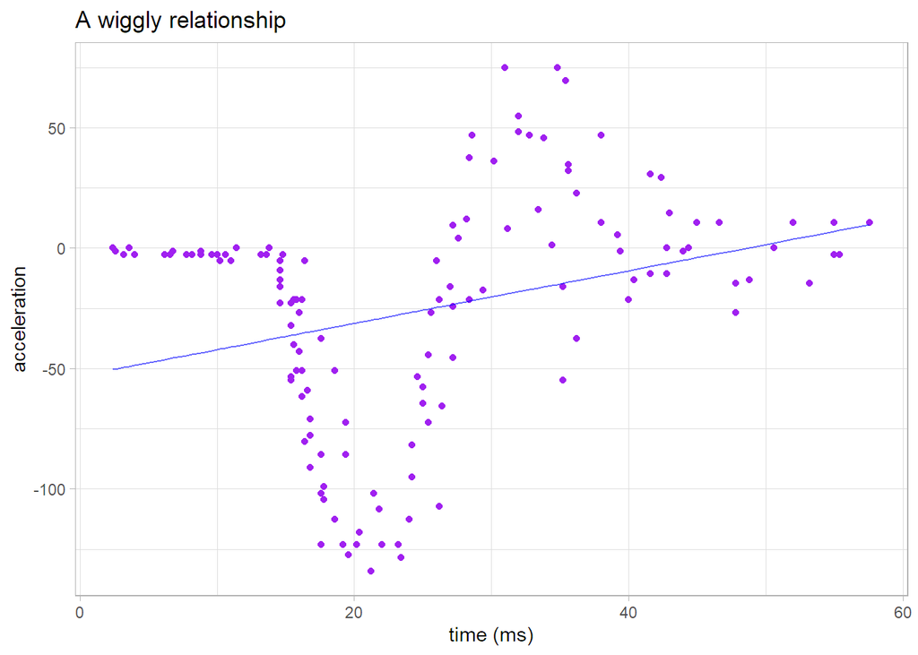

```r
  f1Predicted <- f1Basis %>% mutate(yhat = fitted(f1Fitted)) %>% arrange(x1)

  p + geom_line(data = f1Predicted, aes(x1, yhat), col = 'blue', alpha = 0.6)
```

Clearly pretty poor - if it were classical statistics I would now look to fit statistics, inference and assumptions. No need, we’re evaluating solely on predictive performance. Fair to say it’s not complex enough. Let’s go big.

# Consider different $f$

I can turn up the complexity by turning a handle - the degree parameter. Twenty is plenty, by way of example.

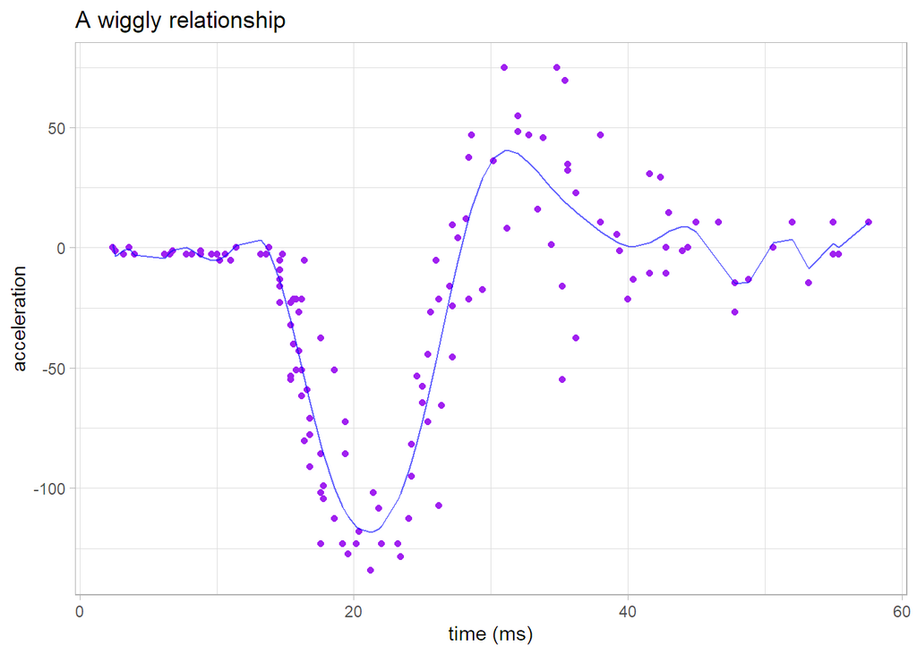

```r
  # a complex model
  fbigFitted <- lm(accel ~ poly(times, 20), data = mcycle)

  fbigPredicted <- mcycle %>% mutate(yhat = fitted(fbigFitted)) %>% arrange(times)

  p + geom_line(data = fbigPredicted, aes(times, yhat), col = 'blue', alpha = 0.6)
```

Is that good? Better at least. But, we want to take the human out of this a bit.

# Basis functions

Polynomials are constructed from a bunch of monomials - you can think of these as basis functions. Every additional monomial adds a column to $\mathbf{X}$. They look like this:

```r
  # construct using "raw" polynomials - usually you'd use orthogonal, but those are details
  f4Basis <- cbind(1, poly(mcycle$times, 4, raw = T))
  head(f4Basis)
```

```
##          1     2       3         4
## [1,] 1 2.4  5.76  13.824   33.1776
## [2,] 1 2.6  6.76  17.576   45.6976
## [3,] 1 3.2 10.24  32.768  104.8576
## [4,] 1 3.6 12.96  46.656  167.9616
## [5,] 1 4.0 16.00  64.000  256.0000
## [6,] 1 6.2 38.44 238.328 1477.6336
```

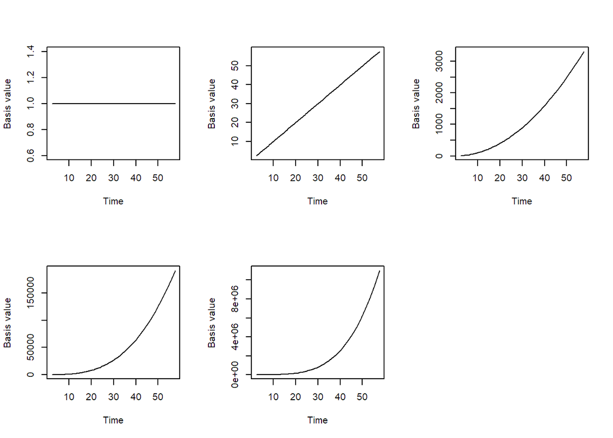

```r
  par(mfrow = c(2,3))

  for(i in 1:5){
    plot(mcycle$times, f4Basis[,i], xlab = "Time", ylab = "Basis value", type = 'l')
  }
```

Again, given $f$, fit to the data using our squared-error loss.

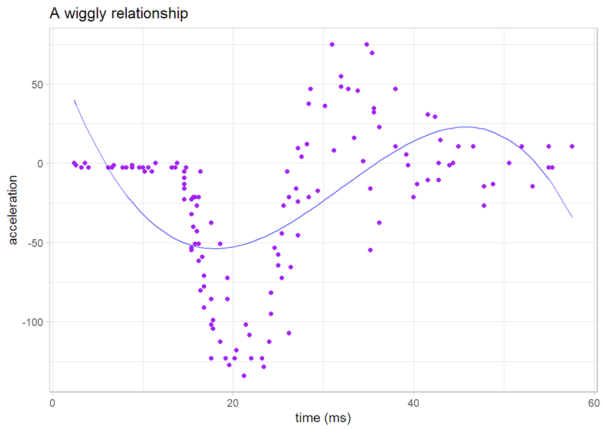

```r
  # fit that back to our data - several basis functions
  f4Basis <- data.frame(y = mcycle$accel, f4Basis)
  f4Fitted <- lm(y ~ ., data = f4Basis)

  f4Predicted <- f4Basis %>% mutate(yhat = fitted(f4Fitted)) %>% arrange(X1)

  p + geom_line(data = f4Predicted, aes(X1, yhat), col = 'blue', alpha = 0.6)
```

# Create an $f$ generating process

To make this ML-like, we want our process to search over differing complexities. Here I create a bunch of candidate $f$ of increasing complexity by turning the handle on the polynomial degree.

```r
  # make lots of f

  basisList <- list()

  for(i in 1:20){

    basisList[[i]] <- data.frame(y = mcycle$accel, poly(mcycle$times, degree = i, raw = T))

    }

  # fit them all using OLS

  modelList <- lapply(basisList, function(q){lm(y~., data = q)})
```

With that in hand, which is best? We can’t use $R^2$ or residual error - this is not generalisation error and will **always** favour the complex model. I can cheat a little - the adjusted $R^2$ has a penalty for the number of parameters.

```r
  adjRsq <- lapply(modelList, function(q){summary(q)$adj.r.squared}) %>% unlist()

  which.max(adjRsq)
```

```
## [1] 12
```

The best one is model 12 - let’s look at it.

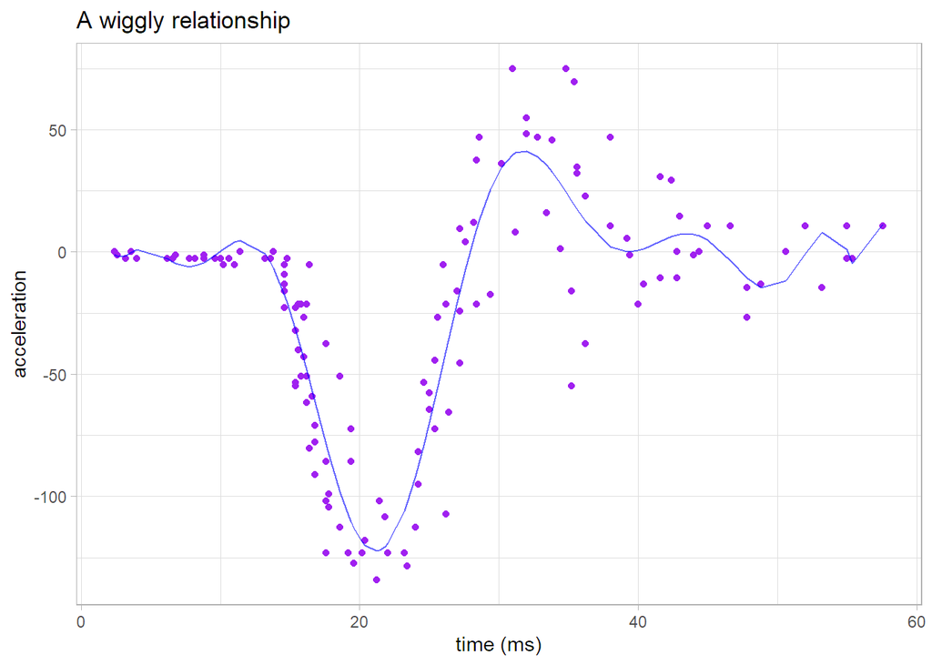

```r
  bestModel <- basisList[[12]] %>% mutate(yhat = fitted(modelList[[12]])) %>% arrange(X1)

  p + geom_line(data = bestModel, aes(X1, yhat), col = 'blue', alpha = 0.6)
```

Polynomials are a bit old school. Splines, like seen in Generalised Additive Models, are superior. This is just a simple change of basis - here I’ll use cubic $b$-spline bases. Fit with squared error loss.

```r
  # make lots of f
  library(splines)

  basisList <- list()

  for(i in 1:20){

    basisList[[i]] <- data.frame(y = mcycle$accel, bs(mcycle$times, df = i+2))

    }


  modelList <- lapply(basisList, function(q){lm(y~., data = q)})
```

Determine which is best.

```r
  adjRsq <- lapply(modelList, function(q){summary(q)$adj.r.squared}) %>% unlist()

  which.max(adjRsq)
```

```
## [1] 9
```

Which gives us:

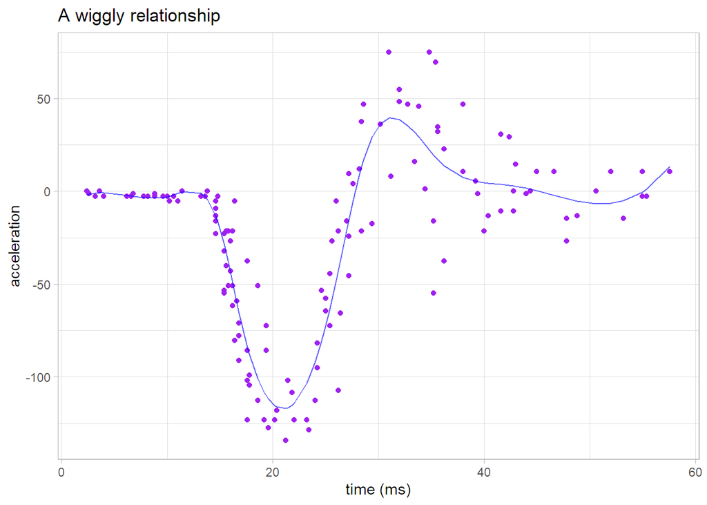

```r
  bestModel <- basisList[[9]] %>% mutate(yhat = fitted(modelList[[9]]))

  p + geom_line(data = bestModel, aes(mcycle$times, yhat), col = 'blue', alpha = 0.6)
```

A superior fit with less parameters (polynomials have an undesirable global behaviour). This is due to the local nature of the $b$-splines.

# Use a good measure of generalisation error

To make this really like ML, we should base it on a direct measure of generalisation error, rather than rely on a penalised fit measure. One good reason is that the penalties are theoretically derived and may not apply generally - the number of parameters isn’t always a good measure of complexity.

```r
  # create a train and validation set
  set.seed(234324)

  # about 60% for training
  trainInd <- sample(1:nrow(mcycle), size = 80, replace = F)

  trainDat <- mcycle[trainInd,]

  validationDat <- mcycle[-trainInd,]

 # make lots of f and fit them with OLS

  error <- numeric(30)

  for(i in 1:30){

    currentModel <- lm(accel ~ bs(times, df = i+3, Boundary.knots = c(min(mcycle$times), max(mcycle$times))), data = trainDat)

    yhat <- predict(currentModel, newdata = validationDat)

    error[i] <- sum((validationDat$accel - yhat)^2)

    }
```

Determine which is best, this time based on the validation data.

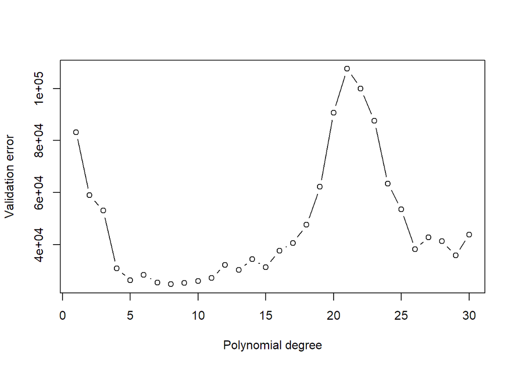

```r
  plot(error, xlab = "Polynomial degree", ylab = "Validation error", type = 'b')
```

In truth, anything with around 5 to 10 knots seems OK for this validation data. Pretty small dataset, so I’d be concerned about sensitivity to dividing up the data for test/train.

# Was this ML?

Somewhat, but pretty restrictive. We *are* following common principles though:

- Consider the nature of our $y$ and $x$s to inform the modelling
- Devise/use a process for generating $f$ of varying complexity
- *Given* $f$, fit to the data with an appropriate loss function
- Select between the models based on generalisation error i.e. control the complexity, avoid over/under-fitting

If we used a different approach to basis formation it could be our next set of models, trees.